# US Most Harmful Weather-Related Events since 1950

### Synopsis

The present report answers the questions of which weather-related events in the United States have had the largest impact measured as fatalities and injuries in populations, as well as the economic losses in property and crops.  
The analysis was performed using the info recorded in the **U.S. National Oceanic and Atmospheric Administration’s (NOAA)** storm database that stores quantitative and qualitative data since 1950.  
**Tornados** are the main cause of fatalities and injuries, and the third in economic losses during the period covered by the dataset.  
**Floods** are the main cause of economic losses in property and crops.

### Data Processing

The first step is to load the required packages.

```r
# Load required packages
require(data.table)
require(ggplot2)
```

Then loads the data from a bz2 file in the ‘RepData_PeerAssessment2’ directory within the current working directory.

```r
# Load data
df <- read.csv('StormData.csv.bz2', stringsAsFactors = FALSE)
# Convert dataframe into datatable object and remove unused dataframe
dt <- data.table(df)
rm(df)
```

Explore the structure of the dataset.

```r
str(dt)
```

```
## Classes 'data.table' and 'data.frame':   902297 obs. of  37 variables:
##  $ STATE__   : num  1 1 1 1 1 1 1 1 1 1 ...
##  $ BGN_DATE  : chr  "4/18/1950 0:00:00" "4/18/1950 0:00:00" "2/20/1951 0:00:00" "6/8/1951 0:00:00" ...
##  $ BGN_TIME  : chr  "0130" "0145" "1600" "0900" ...
##  $ TIME_ZONE : chr  "CST" "CST" "CST" "CST" ...
##  $ COUNTY    : num  97 3 57 89 43 77 9 123 125 57 ...
##  $ COUNTYNAME: chr  "MOBILE" "BALDWIN" "FAYETTE" "MADISON" ...
##  $ STATE     : chr  "AL" "AL" "AL" "AL" ...
##  $ EVTYPE    : chr  "TORNADO" "TORNADO" "TORNADO" "TORNADO" ...
##  $ BGN_RANGE : num  0 0 0 0 0 0 0 0 0 0 ...
##  $ BGN_AZI   : chr  "" "" "" "" ...
##  $ BGN_LOCATI: chr  "" "" "" "" ...
##  $ END_DATE  : chr  "" "" "" "" ...
##  $ END_TIME  : chr  "" "" "" "" ...
##  $ COUNTY_END: num  0 0 0 0 0 0 0 0 0 0 ...
```

[output cut: 24 more lines]

And finally load the definition of a function used to convert data about economic losses into million of dollars.

```r
# Function to convert in economic units
to_DollarAmount <- function(amount, unit = ''){
    # Convert 'amount' dollars depending on the value of 'unit'
    # If 'unit' is not in [K,k,M,m,B,b] assumes that 'amount' is in dollars
    x <- ifelse(unit == 'K' | unit == 'k', amount * 1000,
                ifelse(unit == "M" | unit == 'm', amount * 1000000,
                       ifelse(unit == "B" | unit == 'b', amount * 1000000000,
                              amount
                              )
                       )
                )
    # Return transformed to millions
    return(x/1000000)
}
```

Build the first working datatable, `dtw_1`, to deal with human-related losses.  
Four new datatables are created:

- `top_events_fat` to store the top 10 list of Types of Events ordered by the number of accumulated Fatalities.
- `top_states_fat` to store the top 3 list of States with the largest number of Fatalities due to most harmful type of events measured as number of death people.
- `top_events_inj` to store the top 10 list of Types of Events ordered by the number of accumulated Injuries.
- `top_states_inj` to store the top 3 list of States with the largest number of Injuries due to most harmful type of events measured as number of injured people.

```r
# Select rows with Fatalities or Injuries > 0
# Select and rename columns to retrieve
dtw_1 <- dt[FATALITIES > 0 | INJURIES > 0,
            list(Event = EVTYPE, State = STATE,
                 Fatalities = FATALITIES, Injuries = INJURIES)
            ]
# Lists based on Fatalities
# Top 10 list of Type of Events ordered by the number of Fatalities
top_events_fat <- dtw_1[ ,
                      list(Fatalities = sum(Fatalities)),
                      by = Event
                      ][order(-Fatalities)][1:10]
print(top_events_fat)
```

```
##              Event Fatalities
##  1:        TORNADO       5633
##  2: EXCESSIVE HEAT       1903
##  3:    FLASH FLOOD        978
##  4:           HEAT        937
##  5:      LIGHTNING        816
##  6:      TSTM WIND        504
##  7:          FLOOD        470
##  8:    RIP CURRENT        368
##  9:      HIGH WIND        248
## 10:      AVALANCHE        224
```

```r
# Top 3 list of States with most harmful Event measured by the number of death
# people.
top_states_fat <- dtw_1[Event == top_events_fat$Event[1],
                      list(Fatalities = sum(Fatalities),
                           Percentage = sum(Fatalities)/sum(dtw_1$Fatalities)),
                      by = State
                      ][order(-Fatalities)][1:3]
print(top_states_fat)
```

```
##    State Fatalities Percentage
## 1:    AL        617 0.04073952
## 2:    TX        538 0.03552328
## 3:    MS        450 0.02971278
```

```r
# Top 10 list of Type of Events ordered by number of Injuries
top_events_inj <- dtw_1[ ,
                      list(Injuries = sum(Injuries)),
                      by = Event
                      ][order(-Injuries)][1:10]
print(top_events_inj)
```

```
##                 Event Injuries
##  1:           TORNADO    91346
##  2:         TSTM WIND     6957
##  3:             FLOOD     6789
##  4:    EXCESSIVE HEAT     6525
##  5:         LIGHTNING     5230
##  6:              HEAT     2100
##  7:         ICE STORM     1975
##  8:       FLASH FLOOD     1777
##  9: THUNDERSTORM WIND     1488
## 10:              HAIL     1361
```

```r
# Top 3 list of States with most harmful Event measured by the number of injured
# people.
top_states_inj <- dtw_1[Event == top_events_inj$Event[1],
                      list(Injuries = sum(Injuries),
                           Percentage = sum(Injuries)/sum(dtw_1$Injuries)),
                      by = State
                      ][order(-Injuries)][1:3]
print(top_states_inj)
```

```
##    State Injuries Percentage
## 1:    TX     8207 0.05840117
## 2:    AL     7929 0.05642292
## 3:    MS     6244 0.04443243
```

Create the first figure to include in the report section.

```r
# Chart1: Most harmful type of events based on direct fatalities
# First get the order for the horizontal-axis
orderlist_1 <- rev(top_events_fat$Event)

# Start building the chart
g1 <- ggplot(data = top_events_fat,
             aes(x = factor(Event), y = Fatalities))
g1 <- g1 + geom_bar(stat='identity', fill = 'white', color = 'black')
g1 <- g1 + xlab('Events') + ylab('Number of Fatalities')
g1 <- g1 + ggtitle('Most Harmful Types of Events')
g1 <- g1 + scale_x_discrete(limits = orderlist_1)
g1 <- g1 + coord_flip()
```

Create the second figure to include in the report section.

```r
# Chart2: Most harmful type of events based on direct injuries
# First get the order for the horizontal-axis
orderlist_2 <- rev(top_events_inj$Event)

# Start building the chart
g2 <- ggplot(data = top_events_inj,
             aes(x = factor(Event), y = Injuries))
g2 <- g2 + geom_bar(stat='identity', fill = 'white', color = 'black')
g2 <- g2 + xlab('Events') + ylab('Number of Injuries')
g2 <- g2 + ggtitle('Most Harmful Types of Events')
g2 <- g2 + scale_x_discrete(limits = orderlist_2)
g2 <- g2 + coord_flip()
```

Build the second working datatable, `dtw_2`, to calculate and store economic damages measured in million dollars.

The function `to_DollarAmount` is used to transform units (‘K’, ‘M’ and ‘B’) into numeric values to convert figures to million dollars.  
Two new datatables are created:

- `top_events_dmg` store the list of the 10 most harmful Type of Events ordered by the economic damage in million dollars in Property and Crops.
- `top_states_dmg` store the list of the 3 most affected States ordered by dollar amount of damages to Property and Crops.

```r
# Select rows with property and/or crop economic damages > 0
# Select and rename columns to retrieve, and applies function to convert and
# calculate dollar amounts in millions.
dtw_2 <- dt[PROPDMG > 0 | CROPDMG > 0,
            list(Event = EVTYPE, State = STATE,
                 PropDmgT = to_DollarAmount(PROPDMG, PROPDMGEXP),
                 CropDmgT = to_DollarAmount(CROPDMG, CROPDMGEXP)
                 )
            ]
# Accumulate total amount of damages in million dollars by event, store in
# TotDmg variable and order by it.
dtw_2 <- dtw_2[ , TotDmg := (PropDmgT + CropDmgT)][order(-TotDmg)]

# Eliminates unused columns
dtw_2 <- dtw_2[ , c('PropDmgT', 'CropDmgT') := NULL]

# Accumulates total amount of damages by State and Event
dtw_2 <- dtw_2[ , lapply(.SD, sum), by = c('State', 'Event')]

# Top 10 list of Type of Event ordered by amount of economic damage
top_events_dmg <- dtw_2[ ,
                      list(TotalDmg = round(sum(TotDmg))),
                      by = Event
                      ][order(-TotalDmg)][1:10]
print(top_events_dmg)
```

```
##                 Event TotalDmg
##  1:             FLOOD   150320
##  2: HURRICANE/TYPHOON    71914
##  3:           TORNADO    57352
##  4:       STORM SURGE    43324
##  5:              HAIL    18758
##  6:       FLASH FLOOD    17562
##  7:           DROUGHT    15019
##  8:         HURRICANE    14610
##  9:       RIVER FLOOD    10148
## 10:         ICE STORM     8967
```

```r
# Top 3 list of States ordered by amount of economic damage
top_states_dmg <- dtw_2[ ,
                      list(TotalDmg = round(sum(TotDmg))),
                      by = State
                      ][order(-TotalDmg)][1:3]
print(top_states_dmg)
```

```
##    State TotalDmg
## 1:    CA   127116
## 2:    LA    61302
## 3:    FL    45413
```

Create the third plot to include in the report section.

```r
# Chart3: Most harmful type of events based on direct economic damages on
# property and crops.
# Order the horizontal-axis
#orderlist_3 <- rev(top_events_dmg$Event)

# Start building the chart
g3 <- ggplot(data = top_events_dmg,
             aes(x = factor(Event), y = TotalDmg))
g3 <- g3 + geom_bar(stat='identity', fill = 'white', color = 'black')
g3 <- g3 + xlab('Events') + ylab('$ Millions')
g3 <- g3 + ggtitle('Most Harmful Types of Events')
g3 <- g3 + scale_x_discrete(limits = rev(top_events_dmg$Event))
g3 <- g3 + coord_flip()
```

### Results

#### 1. Across the United States, which types of events (as indicated in the EVTYPE variable) are most harmful with respect to population health?

##### a. Most harmful Events based on Fatalities

The following graph includes the list of the most harmful Type of Events over the period recorded in the dataset, ordered by the number of direct Fatalities caused.

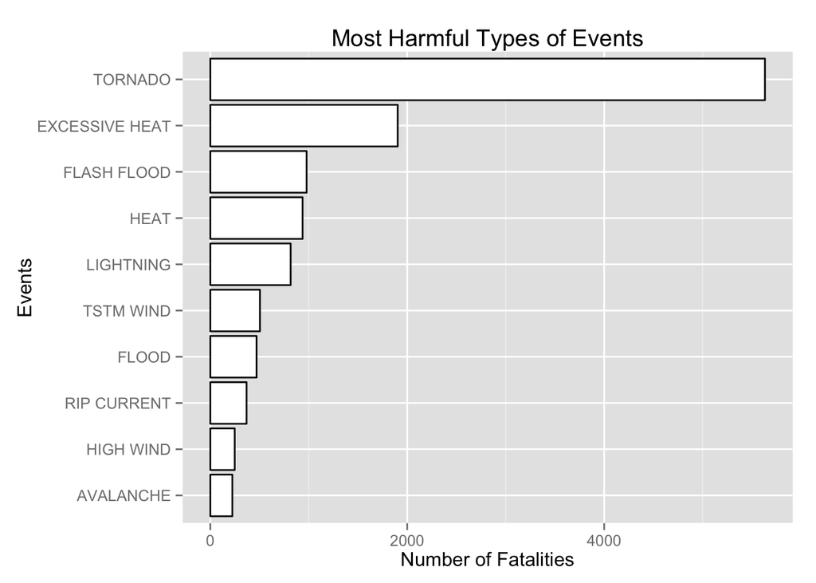

The most harmful type of event measured as the number of fatalities over the period sampled, is the **TORNADO** event. It caused **5633** direct fatalities.

The US State with the largest amount of recorded deaths due to this type of events is **AL** with **617** fatalities, representing a **4.1%** of total number of deaths.

##### b. Most harmful Events based on Injuries

The next plot includes the list of the most harmful Type of Events over the period recorded in the dataset, ordered by the number of direct Injuries caused.

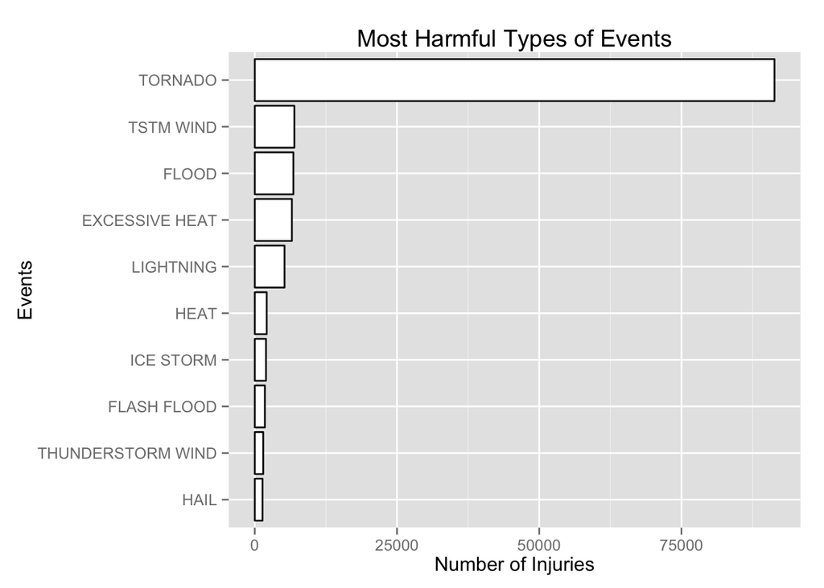

Taken the number of injured people, the most harmful type of event in the dataset, is the **TORNADO** event, that caused **91346** direct Injuries.

The US State with the largest amount of injured people is **TX** that suffered **8207** injuries, accounting for **5.8%** of the total.

#### 2. Across the United States, which types of events have the greatest economic consequences?

> For this report it is assumed that all the information provided is correct.  
> It is noted, however, that the dataset includes some figures that seems to be wrong. See the discussion in the forum in this [link](https://class.coursera.org/repdata-016/forum/thread?thread_id=130).

The types of events that have the greatest economic impact are included in the following chart, where horizontal-axis accounts for the amount of direct economic damages measured in current $ million.

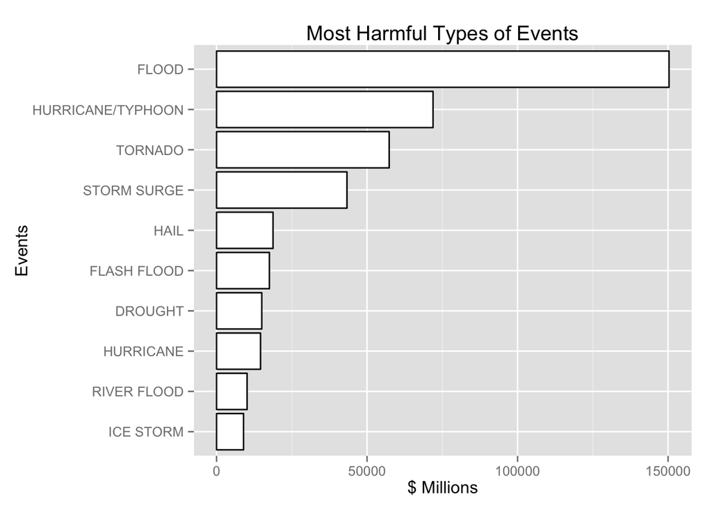